# Assignment 7 - Visualization - Some aspects of ggplot2

Andrew Johnson

How to do it?:

Open the Rmarkdown file of this assignment (link) in Rstudio.

Right under each question, insert a code chunk (you can use the hotkey Ctrl + Alt + I to add a code chunk) and code the solution for the question.

Knit the rmarkdown file (hotkey: Ctrl + Alt + K) to export an html.

Publish the html file to your Githiub Page.

Submission: Submit the link on Github of the assignment to Canvas

Use the data of your own. Produce the following types of plots and comment on each plot. Plots should be meaningful. If you use the data we used in class, make sure the plots are not the same as the ones in the slides. All plots should have title, caption, appropriate labels on x and y-axis.

```r
library(ggplot2)
library(dplyr)
titanic <- read.csv("C:/Users/student/Downloads/titanic.csv")
```

Make a plot using facet_wrap by one categorical variable (facet_wrap(~variable1))

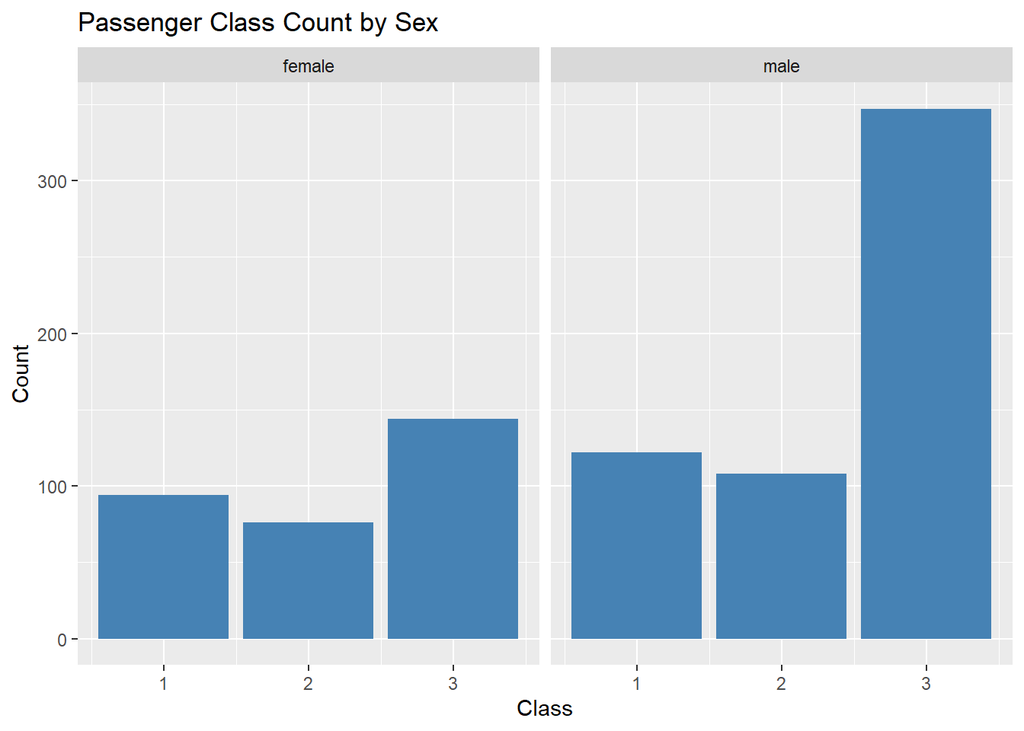

```r
ggplot(titanic, aes(x = Pclass)) +
  geom_bar(fill = "steelblue") +
  facet_wrap(~Sex) +
  labs(title = "Passenger Class Count by Sex", x = "Class", y = "Count")
```

```r
#This plot shows how passenger classes are distributed separately for males and females
```

Make a plot using facet_wrap by two categorical variables (facet_wrap(~variable1+variable2))

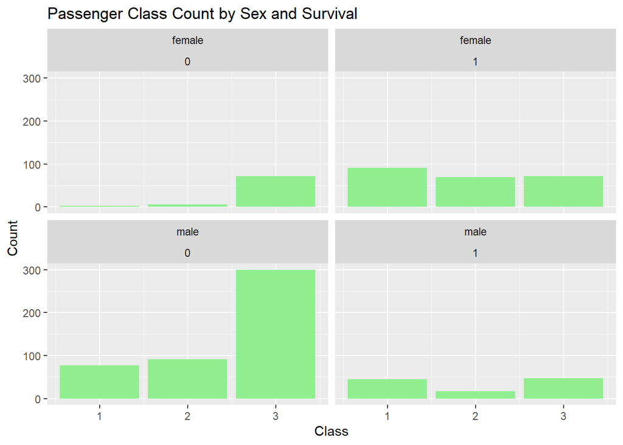

```r
ggplot(titanic, aes(x = Pclass)) + geom_bar(fill = "lightgreen") + facet_wrap(~Sex + Survived) + labs(title = "Passenger Class Count by Sex and Survival", x = "Class", y = "Count")
```

```r
#Using two variables lets us see patterns like survival rates within each class and sex combination.
```

Make a plot using position =‘dodge’.

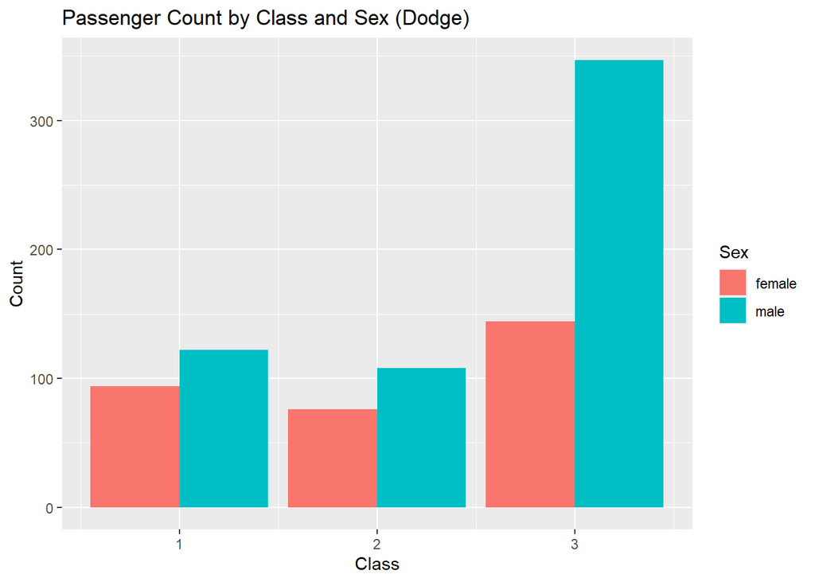

```r
ggplot(titanic, aes(x = Pclass, fill = Sex)) +
  geom_bar(position = "dodge") +
  labs(title = "Passenger Count by Class and Sex (Dodge)", x = "Class", y = "Count")
```

```r
#This makes it easy to compare counts of males and females by class
```

Make a plot using position =‘fill’.

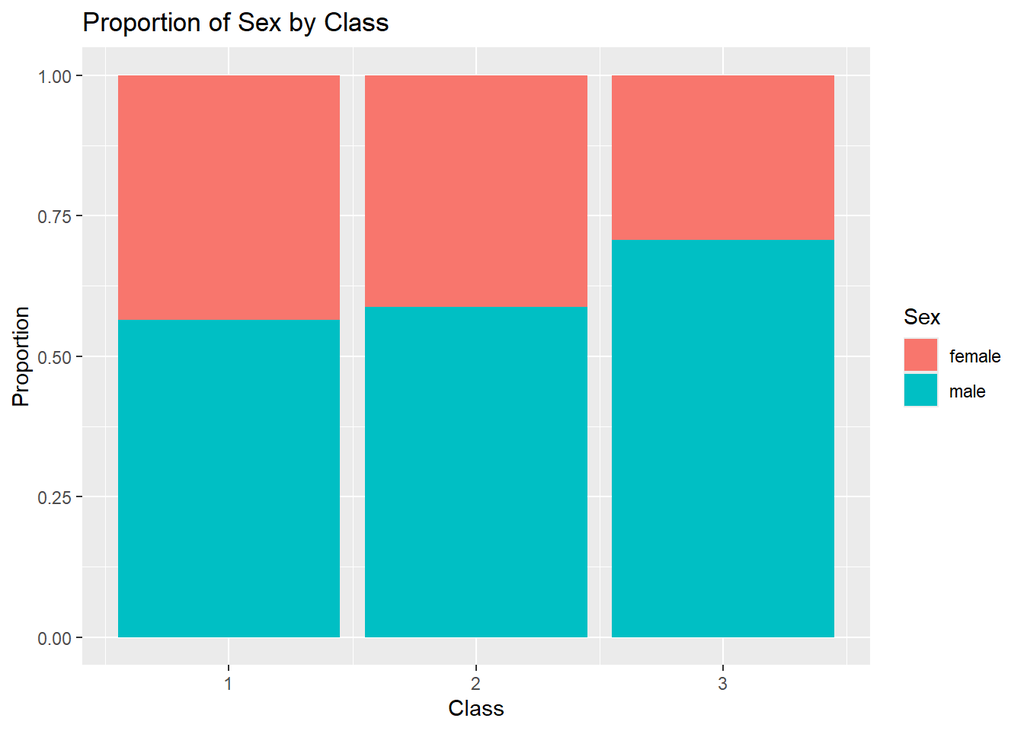

```r
ggplot(titanic, aes(x = Pclass, fill = Sex)) +
  geom_bar(position = "fill") +
  labs(title = "Proportion of Sex by Class", x = "Class", y = "Proportion")
```

```r
#Instead of counts, this shows proportions by class
```

Make a plot using geom_col.

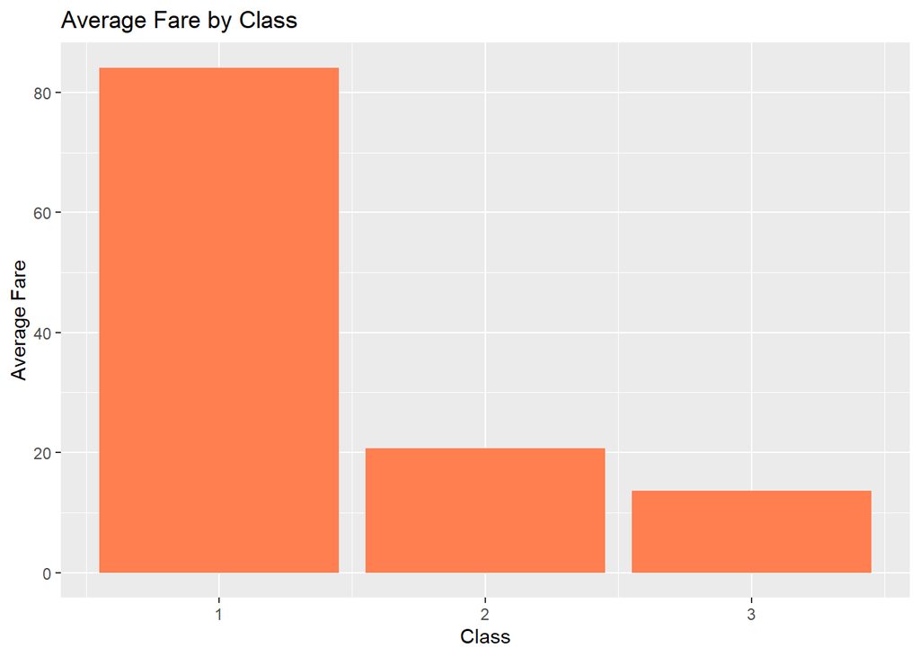

```r
avg_fare <- titanic %>%
  group_by(Pclass) %>%
  summarise(mean_fare = mean(Fare, na.rm = TRUE))

ggplot(avg_fare, aes(x = Pclass, y = mean_fare)) +
  geom_col(fill = "coral") +
  labs(title = "Average Fare by Class", x = "Class", y = "Average Fare")
```

```r
#This is used to show average fare by class
```

Change the theme of one of your plots.

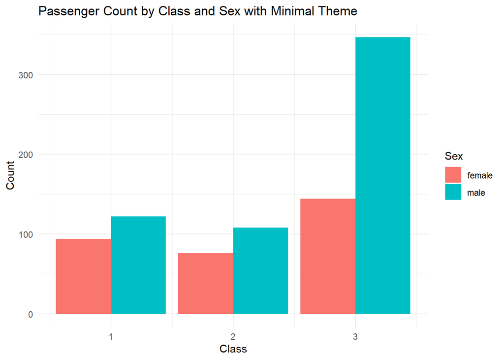

```r
ggplot(titanic, aes(x = Pclass, fill = Sex)) +
  geom_bar(position = "dodge") +
  theme_minimal() +
  labs(title = "Passenger Count by Class and Sex with Minimal Theme", x = "Class", y = "Count")
```

```r
#This removes background of the original graph
```

Make a plot using combo filter + ggplot

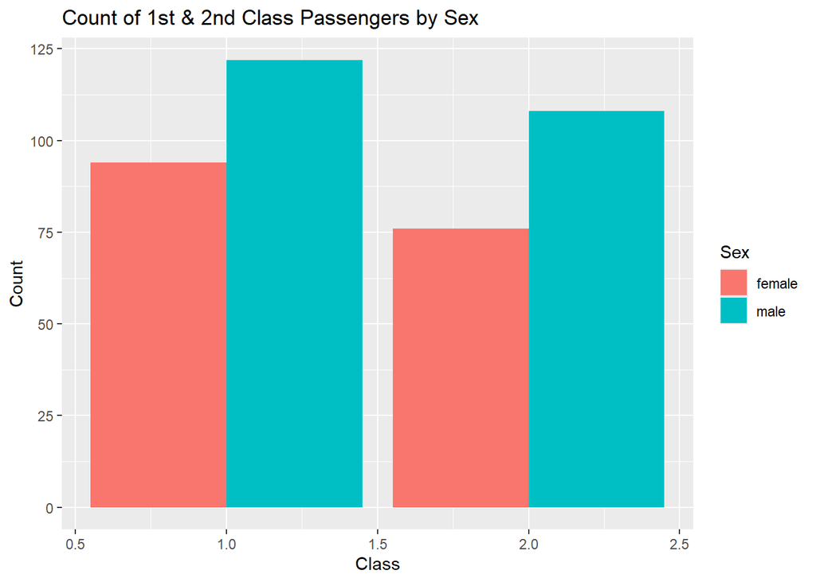

```r
titanic %>%
  filter(Pclass %in% c(1, 2)) %>%
  ggplot(aes(x = Pclass, fill = Sex)) +
  geom_bar(position = "dodge") +
  labs(title = "Count of 1st & 2nd Class Passengers by Sex", x = "Class", y = "Count")
```

```r
#This helps focus the plot
```

Make a plot using combo group_by + summarise + geom_col

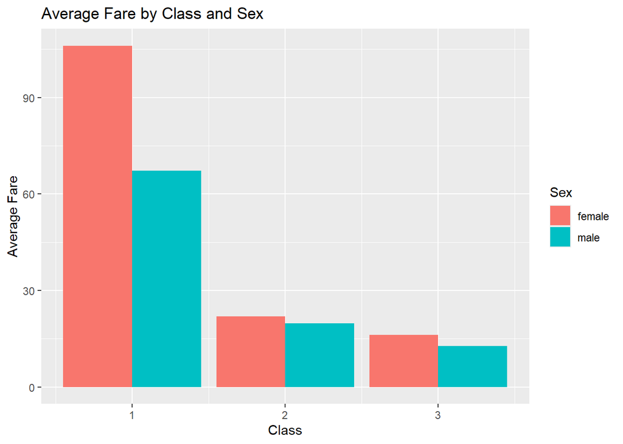

```r
avg_fare_sex <- titanic %>%
  group_by(Pclass, Sex) %>%
  summarise(mean_fare = mean(Fare, na.rm = TRUE))

ggplot(avg_fare_sex, aes(x = Pclass, y = mean_fare, fill = Sex)) +
  geom_col(position = "dodge") +
  labs(title = "Average Fare by Class and Sex", x = "Class", y = "Average Fare")
```

```r
#This shows summarized data, comparing average fares between males and females within each class
```

Save a plot and put a link of the plot to your Github Webpage. To link a plot abc.png you just need to insert the following on the README.md

```r
[Link to the plot](abc.png)
```

In this question, we will use the Covid19 vaccination data for the US. The data and data dictionary can be found at the below link:

Data

```r
library(tidyverse)
df <- read_csv('https://bryantstats.github.io/math421/data/vaccinations-by-manufacturer.csv')
```

Geom_point makes scatter plots, which plot two numeric (or Date) variables. A third categorical variable is often brought in for color. For example, we can compare different vaccine types used in the US by

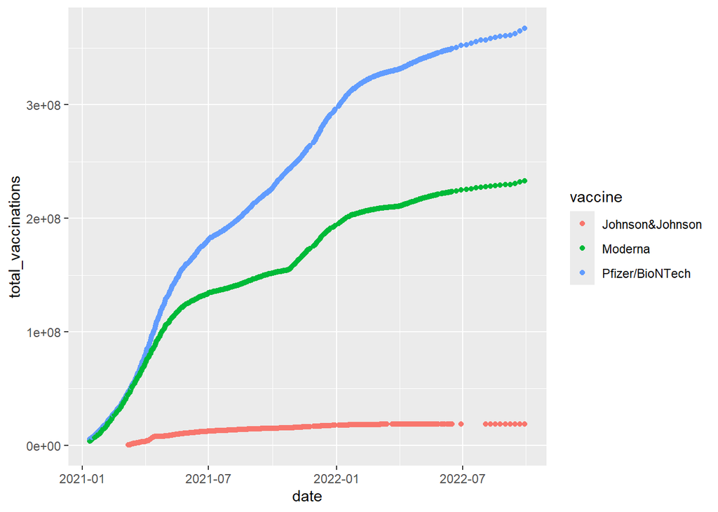

```r
df %>%
  filter(location=='United States') %>%
  ggplot()+
  geom_point(mapping = aes(x = date,
                                    y = total_vaccinations,
                                    color = vaccine))
```

Do the follows.

Use geom_point to compare the vaccines used by date in Argentina in 2022.

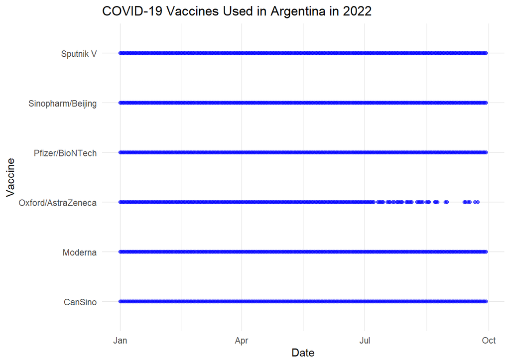

```r
argentina_2022 <- df %>%
  filter(location == "Argentina" & format(as.Date(date), "%Y") == "2022")
ggplot(argentina_2022, aes(x = as.Date(date), y = vaccine)) +
  geom_point(color = "blue", alpha = 0.6) +
  labs(title = "COVID-19 Vaccines Used in Argentina in 2022",
       x = "Date",
       y = "Vaccine") +
  theme_minimal()
```

```r
#Each point represents a vaccine reported on a given date
```

Change geom_point to geom_line in the above codes to have the corresponding line plots.

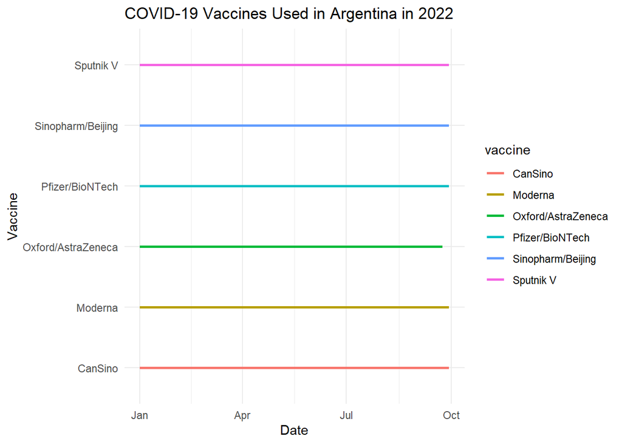

```r
ggplot(argentina_2022, aes(x = as.Date(date), y = vaccine, group = vaccine, color = vaccine)) +
  geom_line(size = 1) +
  labs(title = "COVID-19 Vaccines Used in Argentina in 2022",
       x = "Date",
       y = "Vaccine") +
  theme_minimal()
```

```r
#This shows trends over time instead of individual points
```

(Using the same dataset as in 10.) Sometime we need to do some calculations on the data before plotting. For example, the below codes is to compare the total vaccines (including all types of vaccines) by date between the US and the EU

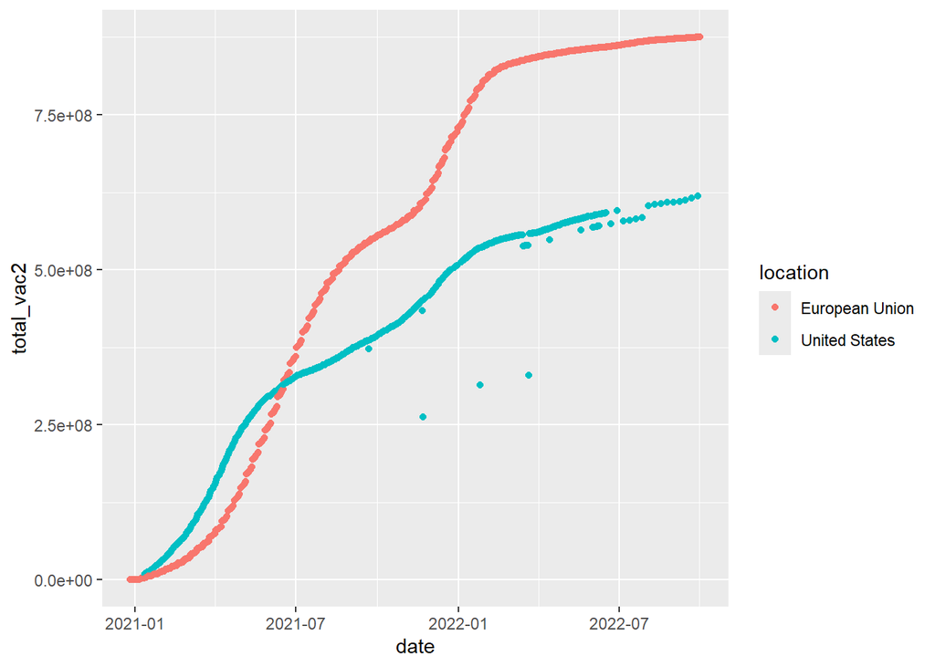

```r
# the total vaccines (including all types of vaccines) by date
d1 <- df %>%
  filter(location %in% c('United States', 'European Union')) %>%
  group_by(date, location) %>%
  summarise(total_vac2=sum(total_vaccinations, na.rm=TRUE))

# Plot
d1 %>%
  ggplot()+
  geom_point(mapping=aes(x=date,
                         y=total_vac2,
                         color=location))
```

Notice that the above codes could be piped in one

```r
df %>%
  filter(location %in% c('United States', 'European Union')) %>%
  group_by(date, location) %>%
  summarise(total_vac2=sum(total_vaccinations, na.rm=TRUE)) %>%
  ggplot()+
  geom_point(mapping=aes(x=date,
                         y=total_vac2,
                         color=location))
```

Do the follows.